# UA_MVHW3

## Machine Vision - HW 3: 3D Reconstruction

## Section 1: Sparse Reconstruction

So, what is this the Reconstruciton that is also Sparse?

Sparse reconstruction recovers only a limited set of key 3D points from stereo images using matched features, rather than computing depth for every pixel. It gives an overall structure of the scene without dense data.

## Important!

**This work has been quite messy, since I worked on it on different days.**

**Also, I tried to run each part separately.**

**However, because of some errors I got, and since they could not be solved.**

**I decided to merge certain steps after a while.**

**I had serious issues with the theoretical concepts, and I just hope that I understood everything correctly.**

- Imports & Environment Setup

```python
import numpy as np
import matplotlib.pyplot as plt
from scipy.io import loadmat
import cv2  # Although not strictly needed for the fundamental matrix, handy for image I/O.
import os
import random
from mpl_toolkits.mplot3d import Axes3D
```

- Utility Functions

```python
# Suppose your file is named 'intrinsics.mat' and includes variables 'K1' and 'K2'
data_intrinsics = loadmat('intrinsics.mat')
K1 = data_intrinsics['K1']  # shape (3, 3)
K2 = data_intrinsics['K2']  # shape (3, 3)

print("K1:\n", K1)
print("K2:\n", K2)

#Explanation:
#loadmat() reads the .mat file and returns a dictionary of variable names.
#K1 and K2 are the intrinsic matrices for your two cameras (focal length, principal point, etc.).
#These will be critical when you compute the Essential Matrix (Part 3) and for final 3D reconstruction steps.
```

```
K1:
 [[1.5204e+03 0.0000e+00 3.0232e+02]
 [0.0000e+00 1.5259e+03 2.4687e+02]
 [0.0000e+00 0.0000e+00 1.0000e+00]]
K2:
 [[1.5204e+03 0.0000e+00 3.0232e+02]
 [0.0000e+00 1.5259e+03 2.4687e+02]
 [0.0000e+00 0.0000e+00 1.0000e+00]]
```

## Part 1: Implementing the Eight-Point Algorithm in Python (.ipynb format):

- Loading data from .mat files using scipy.io.loadmat.
- Normalizing coordinates with the scale parameter M.
- Constructing the matrix A for the eight-point method.
- Solving for the fundamental matrix F via SVD.
- Rank-2 enforcement on F.
- Unnormalizing F to revert the normalization step.
- Visualizing some epipolar lines on im1 and im2 to confirm correctness.

In this section...

- We first computed the fundamental matrix F using the eight-point algorithm applied to a set of matched 2D points in both images. After normalizing the coordinates by a scale factor, we formed a linear system and solved for F by singular value decomposition, then enforced the rank-two condition on the resulting matrix.
- We visualized a few epipolar lines to confirm the correctness of F, and we refined the matched points in the second image by searching along those lines (epipolar correspondences).
- Next, we integrated the intrinsic camera matrices K1 and K2 with F to obtain the essential matrix E for the temple image pair, which captures the cameras’ internal parameters.
- We decomposed E to recover multiple potential camera rotations and translations, then selected the correct (R, t) by quickly triangulating a subset of points and choosing the solution that placed the most 3D points in front of the cameras (a cheirality check).
- Finally, we used the chosen (R, t) to build two camera projection matrices and performed full triangulation on all matched points, yielding a 3D reconstruction of the scene. We verified the quality of the reconstruction through a low reprojection error (indicating that the 3D points project back onto each image accurately) and by plotting the resulting 3D points, thereby completing the sparse reconstruction for the temple images.

```python
# Load the fundamental matrix from a .mat file
# Assuming the file is named 'fundamental_matrix.mat' and contains 'F' of course.
def plot_epipolar_lines(F, pts, img, ax, color='yellow'):
    """
    Plots epipolar lines on 'img' for the given list of points 'pts' using the fundamental matrix F.
    'ax' is the matplotlib axes to draw on.
    """
    ax.imshow(img, cmap='gray')
    ax.axis('off')

    # For each point in pts, compute the corresponding epipolar line in 'img'
    # pts: Nx2 array of points (x, y)
    for (x, y) in pts:
        line = F @ np.array([x, y, 1.0])  # line = F * p
        # line: a*x + b*y + c = 0
        # If b != 0, we can parametrize y = -(a/b)*x - c/b
        xs = np.array([0, img.shape[1]])  # from x=0 to x=width
        if abs(line[1]) > 1e-6:
            ys = -(line[0]*xs + line[2]) / line[1]
            ax.plot(xs, ys, color=color, linewidth=1)

    # Also plot the points themselves
    ax.scatter(pts[:,0], pts[:,1], s=30, facecolors='none', edgecolors='r')
```

- The Eight-Point Algorithm: We define a function `eight_point(pts1, pts2, M)` that:
- - Normalizes pts1, pts2 by dividing by M
- - Constructs the A matrix
- - Solves via SVD (A f = 0)
- - Enforces rank-2 on F
- - "Unnormalizes" F

```python
def eight_point(pts1, pts2, M):
    """
    Estimate the fundamental matrix using the eight-point algorithm.

    Arguments:
        pts1: (N, 2) array of matched points (x, y) in image 1.
        pts2: (N, 2) array of matched points (x, y) in image 2.
        M:   Scale parameter for normalization (e.g., max(width, height) of the images).

    Returns:
        F: (3, 3) fundamental matrix
    """
    # Normalize coordinates by dividing by M
    pts1_norm = pts1 / M
    pts2_norm = pts2 / M

    # Construct A: [x2*x1, x2*y1, x2, y2*x1, y2*y1, y2, x1, y1, 1]
    N = pts1.shape[0]
    A = np.zeros((N, 9))
    for i in range(N):
        x1, y1 = pts1_norm[i]
        x2, y2 = pts2_norm[i]
        A[i] = [x2*x1, x2*y1, x2,
                y2*x1, y2*y1, y2,
                x1,     y1,    1]

    # Solve A f = 0 via SVD
    U, S, Vt = np.linalg.svd(A)
    f = Vt[-1]  # The last row of V^T
    F_matrix = f.reshape(3, 3)

    # Enforce rank-2 constraint on F
    U_f, S_f, Vt_f = np.linalg.svd(F_matrix)
    S_f[-1] = 0  # force the smallest singular value to 0
    F_rank2 = U_f @ np.diag(S_f) @ Vt_f

    # Unnormalize
    # T = diag(1/M, 1/M, 1)
    T = np.array([[1/M,    0,   0],
                  [  0,  1/M,   0],
                  [  0,    0,   1]])
    F_unnorm = T.T @ F_rank2 @ T
    return F_unnorm
```

- Loading Data from .mat Files

```python
data_folder = "C:\\Users\\Umut Akti\\Desktop\\HWU ROBOTICS\\HWU Semester 2\\B31MV - MacVision\\MacVis Works\\MacVis_HW3"  # Adjust to match your folder structure
corresp_data = loadmat(os.path.join(data_folder, "some_corresp.mat"))
pts1 = corresp_data['pts1']  # shape (N, 2)
pts2 = corresp_data['pts2']  # shape (N, 2)

print("Loaded correspondences:")
print("pts1 shape:", pts1.shape)
print("pts2 shape:", pts2.shape)

# Load images to determine M
im1 = plt.imread(os.path.join(data_folder, "im1.png"))
im2 = plt.imread(os.path.join(data_folder, "im2.png"))

H, W = im1.shape[0], im1.shape[1]
M = max(W, H)
print("Image 1 size:", W, "x", H, ", M =", M)
```

```
Loaded correspondences:
pts1 shape: (110, 2)
pts2 shape: (110, 2)
Image 1 size: 480 x 640 , M = 640
```

- Computing the Fundamental Matrix

```python
F = eight_point(pts1, pts2, M) # Estimate the fundamental matrix
print("Estimated Fundamental Matrix (F):\n", F)
```

```
Estimated Fundamental Matrix (F):
 [[ 3.56440672e-09 -5.92131870e-08 -1.65029959e-05]
 [-1.30829066e-07 -1.31095126e-09  1.12471525e-03]
 [ 3.04775126e-05 -1.08013400e-03 -4.16583180e-03]]
```

- Visualizing the Epipolar Lines

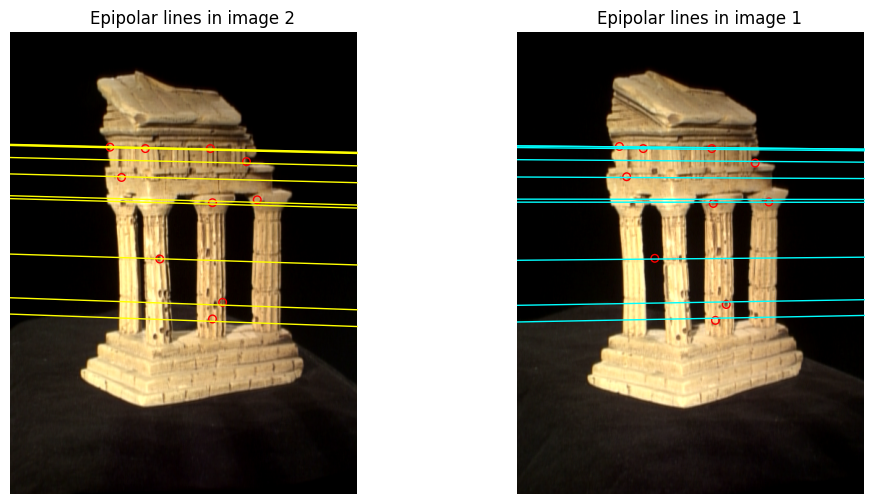

```python
# Randomly sample some points to visualize
sample_count = 10
idxs = np.random.choice(pts1.shape[0], sample_count, replace=False) # Randomly select indices for getting different lines with each iteration.
# Get the sampled points
sample_pts1 = pts1[idxs]
sample_pts2 = pts2[idxs]

fig, axes = plt.subplots(1, 2, figsize=(12, 6))

# Epipolar lines in image 2 from points in image 1
plot_epipolar_lines(F, sample_pts1, im2, axes[0], color='yellow')
axes[0].set_title("Epipolar lines in image 2")

# Epipolar lines in image 1 from points in image 2
# This is F^T for lines from image 2 points
plot_epipolar_lines(F.T, sample_pts2, im1, axes[1], color='cyan')
axes[1].set_title("Epipolar lines in image 1")

plt.show()
```

- Explanation: Eight-Point Algorithm and `intrinsics.mat`
- Why `intrinsics.mat`? The file `intrinsics.mat` typically contains two camera intrinsic matrices, `K1` and `K2`. Each matrix encodes:
- **Focal length** (in pixels),
- **Principal point** (usually at the image center),
- **Skew** (often zero for square pixels).

We load these via:

```
from scipy.io import loadmat
data_intrinsics = loadmat("intrinsics.mat")
K1 = data_intrinsics["K1"]
K2 = data_intrinsics["K2"]
```

More detailed explanation, with more technical and spohisticated information.

## Brief Discussion of Each Step

Here is a concise overview of what each step in Assignment 3 accomplishes:

**1. Eight-Point Algorithm**  
Goal: Estimate the fundamental matrix F from point correspondences.  
Key Idea: Construct a matrix A from normalized coordinates, solve A*f = 0 via SVD, then enforce a rank-2 constraint on F.  
Reason: F relates corresponding points in two images without requiring camera intrinsics.

**2. Epipolar Correspondences**  
Goal: Given F and points in the first image, find matching points in the second image along the corresponding epipolar lines.  
Key Idea: A point (x1, y1) in the first image corresponds to an epipolar line in the second. We search along that line using a similarity measure (for example, SSD or NCC).  
Reason: This ensures that points in the second image align with the epipolar constraint p2^T * F * p1 = 0.

**3. Essential Matrix**  
Goal: Incorporate camera intrinsics (K1, K2) to get a matrix E = K2^T * F * K1.  
Key Idea: The essential matrix encodes the rotation and translation (extrinsics) between the two cameras, bridging the gap from 2D geometry to 3D.  
Reason: Once we have E, we can recover extrinsic parameters up to a sign ambiguity, then choose the correct camera pose.

**4. Triangulation**  
Goal: Compute 3D coordinates from pairs of matched 2D points.  
Key Idea: Each camera has a projection matrix P. We solve P1 * X ≈ p1 and P2 * X ≈ p2 to reconstruct the 3D point X in space.  
Reason: This allows us to build a 3D structure of the scene using only the 2D correspondences.

**5. Full 3D Reconstruction Script**  
Goal: Combine all the above steps (fundamental matrix, essential matrix, epipolar correspondences, and triangulation) to obtain a sparse 3D point cloud of the scene (in this case, the temple).

**Dense Reconstruction (Brief Mention)**

- Rectification: Warp images so epipolar lines become horizontal, reducing the search for correspondence to one dimension.
- Disparity and Depth: Compute per-pixel disparity and convert to depth, yielding a dense 3D map instead of a sparse set of points.

**Where intrinsics.mat Fits In**  
We load K1 and K2 from intrinsics.mat.

- In Part 3 (Essential Matrix), we use E = K2^T * F * K1.
- For triangulation, we use projection matrices P1 = K1 [R1 | t1] and P2 = K2 [R2 | t2], which need the rotation and translation from decomposing E.

Pro Tip: Carefully store or return the extrinsics so you can use them in the dense stage for tasks like image rectification.

**Key Takeaways**

- Loading intrinsics is straightforward: K1 and K2 from intrinsics.mat.
- Use them to compute the essential matrix, then extract extrinsics from it.
- Each step (fundamental matrix, epipolar correspondences, essential matrix, triangulation, rectification, and disparity) builds on the previous step.

## Part 2: Epipolar Correspondance

```python
###########################################
# Part 2 - Epipolar Correspondences
# This function finds corresponding points in im2 for each point in pts1 from im1
# Steps:
#  1) Extract the patch from im1 around (x1, y1)
#  2) Compute the epipolar line in im2 using the fundamental matrix F
#  3) Search for the best match in im2 along the epipolar line
#  4) Return the matched point in im2
###########################################
def epipolar_correspondences(im1, im2, F, pts1, window_size=7, search_range=30):
    """
    Finds corresponding points in im2 for each point in pts1 from im1
    using the fundamental matrix F and a search-based approach along epipolar lines.

    Arguments:
        im1, im2: Grayscale images (numpy arrays).
        F: Fundamental matrix (3x3).
        pts1: Nx2 array of (x,y) points in im1.
        window_size: The side length of the patch around each point.
        search_range: Half-width of the search radius along the epipolar line
                      (or bounding box in x, if you prefer).
    Returns:
        pts2_matched: Nx2 array of matched points in im2.
    """
    # Ensure images are grayscale floats
    if im1.ndim == 3:
        im1 = np.mean(im1, axis=2)  # or use a proper RGB->gray conv
    if im2.ndim == 3:
        im2 = np.mean(im2, axis=2)
    im1 = im1.astype(np.float32)
    im2 = im2.astype(np.float32)

    pad = window_size // 2
    H, W = im2.shape

    # Helper function to extract patch
    def get_patch(img, x, y):
        # Return patch of size window_size x window_size around (x,y)
        # with boundary checks
        x, y = int(round(x)), int(round(y))
        x1, x2 = x-pad, x+pad+1
        y1, y2 = y-pad, y+pad+1

        # If out of range, return None
        if x1 < 0 or x2 > W or y1 < 0 or y2 > H:
            return None
        return img[y1:y2, x1:x2]

    pts2_matched = []

    for (x1, y1) in pts1:
        # 1) Extract the patch from im1 around (x1, y1)
        patch1 = get_patch(im1, x1, y1)
        if patch1 is None:
            pts2_matched.append([np.nan, np.nan])
            continue

        # 2) Epipolar line in im2: l = F * (x1, y1, 1).
        l = F @ np.array([x1, y1, 1.0])
        a, b, c = l

        # 3) We'll search horizontally +/- search_range around x2 guess
        #    We'll find the best match among discrete x2 values
        #    by solving y2 = -(a*x2 + c)/b
        best_score = float('inf')  # or -inf if using correlation
        best_xy = (np.nan, np.nan)

        # We can guess x2 = [x1-search_range, x1+search_range], etc.
        x2_min = max(0, int(round(x1 - search_range)))
        x2_max = min(W-1, int(round(x1 + search_range)))

        for x2_cand in range(x2_min, x2_max+1):
            # compute y2 from line eqn
            # b*y2 + a*x2 + c = 0 => y2 = -(a*x2 + c)/b
            if abs(b) < 1e-9:
                continue
            y2_cand = -(a*x2_cand + c)/b

            # skip if out of image
            if y2_cand < 0 or y2_cand >= H:
                continue

            # extract patch from im2
            patch2 = get_patch(im2, x2_cand, y2_cand)
            if patch2 is None:
                continue

            # Compare patch1 & patch2
            # We'll use simple SSD
            diff = patch1 - patch2
            ssd = np.sum(diff**2)

            if ssd < best_score:
                best_score = ssd
                best_xy = (x2_cand, y2_cand)

        pts2_matched.append(list(best_xy))

    return np.array(pts2_matched)
```

**Substep: Better Representation of the Data**

```
Matched Points in im2:
 [[221.         158.37620071]
 [279.         312.56346503]
 [216.         158.31958084]
 [335.         151.87240816]
 [332.         199.69589968]
 [269.         305.10552217]
 [332.         162.03709808]
 [141.         158.42191507]
 [347.         238.69153977]
 [277.         242.87055555]
 [267.         258.707212  ]
 [271.         195.2772301 ]
 [338.         190.62003262]
 [183.         202.47156872]
 [280.         254.05974108]
 [269.         162.0592276 ]
 [281.         222.78419992]
 [326.         134.39462949]
 [288.         158.1749296 ]
 [380.         486.0966113 ]
 [171.         263.69487534]
 [263.         149.86944019]
 [373.         307.94478394]
 [196.         150.93335679]
 [204.         153.05654886]
 [279.         256.04810246]
 [155.         194.08211355]
 [404.         459.52198056]
 [231.         162.47598075]
 [361.         194.10413272]
 [288.         291.68277564]
 [349.         405.97708568]
 [268.         363.5015295 ]
 [371.         236.27695028]
 [133.         485.36568658]
 [194.         255.52637371]
 [276.         267.05139372]
 [212.         267.05887856]
 [120.         471.61524417]
```

[output cut: 57 more lines]

```
 [268.         235.57602588]
 [226.         200.42986872]
 [132.         120.99539251]
 [137.         109.20654989]
 [217.         382.23294383]
 [274.         302.27360049]
 [138.         186.89554902]
 [285.         375.4290384 ]
 [137.         238.01907589]
 [226.         237.46451901]
 [202.         420.4046278 ]
 [123.         493.4323546 ]
 [207.         310.82295373]
 [156.         235.58000586]]
Valid Matches Count: 110
```

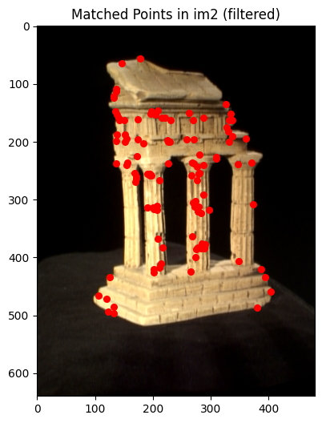

```python
###########################################
 # OPTIONAL PART A: RUN & PRINT RESULTS
###########################################
matched_pts2 = epipolar_correspondences(im1, im2, F, pts1)
print("Matched Points in im2:\n", matched_pts2)

###########################################
# OPTIONAL PART B: FILTER & VISUALIZE
###########################################
valid_indices = ~np.isnan(matched_pts2[:,0])
valid_pts1 = pts1[valid_indices]
valid_pts2 = matched_pts2[valid_indices]
print("Valid Matches Count:", np.sum(valid_indices))

    # # Plot them on im2
fig, ax = plt.subplots(figsize=(8,6))
ax.imshow(im2, cmap='gray')
ax.scatter(valid_pts2[:,0], valid_pts2[:,1], c='r', s=30)
ax.set_title("Matched Points in im2 (filtered)")
plt.show()

###########################################
 # OPTIONAL: Save matched points if needed
###########################################
np.save("matched_pts2.npy", matched_pts2)
```

According to this graph, the matched points appear to be:

- Well-Distributed:
- - They span the entire height of the temple model—from the top roof-like area down to the base. That’s a good sign, meaning your matching algorithm is finding features in different regions (roof edges, columns, corners).
- Focused on Distinct Edges/Features:
- - Many points cluster around pillar edges and decorative details, which aligns with how corner-like features are easier to match. This indicates your epipolar search + patch matching likely keyed in on regions with good texture/contrast.
- Minimal Outliers on the Background:
- - Most points are on the temple itself rather than floating on the black cloth background. That’s reassuring—if you had many red dots floating in empty background areas, it would suggest incorrect matches.
- Sufficient Coverage for Triangulation:
- - Having numerous correspondences across the object (both horizontally and vertically) improves the 3D reconstruction potential. The coverage you have should help produce a decently detailed point cloud in later triangulation steps.

Overall, the matches look fairly reliable and object-focused, which is exactly what you want before computing the essential matrix and moving on to 3D reconstruction.

## Part 3: The Computation of the Essential Matrix

**1-**

F (Fundamental Matrix) is computed from "normalized 2D correspondences". It doesn’t include camera intrinsics.

K1, K2 are 3×3 intrinsics for each camera (focal lengths, principal points, skew).

Essential Matrix E captures the extrinsics (rotation and translation) up to scale:

E=K2^⊤ F K1.

```python
###########################################
# Part 3 - Compute Essential Matrix and Decompose
# Given the fundamental matrix F and intrinsic matrices K1, K2,
# Steps:
#  1) E = compute_essential_matrix(F, K1, K2)
#  2) Decompose E -> up to 4 (R,t) combos
#  3) Choose correct (R,t) by a quick triangulation positivity check
###########################################

def compute_essential_matrix(F, K1, K2):
    """
    E = K2^T @ F @ K1
    """
    return K2.T @ F @ K1

def decompose_essential_matrix(E):
    """
    Returns up to 4 (R, t) solutions from E.
    """
    U, S, Vt = np.linalg.svd(E)

    # Define W
    W = np.array([
        [0, -1, 0],
        [1,  0, 0],
        [0,  0, 1]
    ], dtype=float)

    # Two possible rotations: t and -t
    # R1 = U @ W @ Vt
    # R2 = U @ W.T @ Vt
    ## R1 and R2 are the two possible rotations.
    # since E is rank 2, we can also have two translations.
    # t is the 3rd column of U (or Vt).
    # We can also use the SVD of E to get the translation vector.
    # Translation is not unique, but we can get two possible translations.
    R1 = U @ W  @ Vt
    R2 = U @ W.T @ Vt

    # Ensure det(R)=+1 for valid rotation matrices
    if np.linalg.det(R1) < 0:
        R1 = -R1
    if np.linalg.det(R2) < 0:
        R2 = -R2

    # t is the 3rd column of U
    t = U[:, 2]

    # Four solutions: (R1, +t), (R1, -t), (R2, +t), (R2, -t)
    return [
        (R1,  t),
        (R1, -t),
        (R2,  t),
        (R2, -t)
    ]

################################################
# Minimal triangulation for positivity check
################################################

# This triangulation is not the final one, but a quick check to see how many points are in front of the camera.
# It uses the camera matrices P1 and P2 to triangulate points in 3D space.
# The function returns the 3D points in the camera frame of P1.
def triangulate_points(P1, pts1, P2, pts2):
    """
    Quick triangulation for positivity check only (no final 3D usage).
    """
    N = pts1.shape[0]
    X = np.zeros((N, 3))

    for i in range(N):
        x1, y1 = pts1[i]
        x2, y2 = pts2[i]

        A = np.zeros((4,4))
        A[0] = y1 * P1[2] - P1[1]
        A[1] = x1 * P1[2] - P1[0]
        A[2] = y2 * P2[2] - P2[1]
        A[3] = x2 * P2[2] - P2[0]

        _, _, Vt = np.linalg.svd(A)
        X_hom = Vt[-1]
        X_hom /= X_hom[-1]  # from [X,Y,Z,W]
        X[i] = X_hom[:3]

    return X

# This function is used to count how many points are in front of the camera.
# It triangulates the points and counts how many have z > 0 in the first camera frame.

def do_triangulation_count_positive(pts1, pts2, P1, P2):
    """
    Triangulate quickly, count how many have z>0 in the first camera frame.
    """
    X_3D = triangulate_points(P1, pts1, P2, pts2)
    return np.sum(X_3D[:,2] > 0)

# This function takes the candidates (R,t) and the points in both images.
# It builds the camera matrices and counts how many points have z>0 in the first camera frame.
# It returns the best (R,t) pair that has the most points in front of the camera.
def choose_correct_RT(candidates, pts1, pts2, K1, K2):
    """
    Chooses best (R,t) by counting how many 3D points have z>0.
    Returns (R_best, t_best).
    """
    best_count = -1
    best_RT = None

    for (R, t) in candidates:
        # Build camera matrices
        P1 = K1 @ np.hstack([np.eye(3), np.zeros((3,1))])
        P2 = K2 @ np.hstack([R, t.reshape(3,1)])

        count_pos = do_triangulation_count_positive(pts1, pts2, P1, P2)
        if count_pos > best_count:
            best_count = count_pos
            best_RT = (R, t)

    return best_RT
```

```python
# Demonstration of the functions above
# The follow up from part 1 & 2; we have:
#
# F: fundamental matrix
# pts1, pts2: matched correspondences (Nx2)
# K1, K2: camera intrinsics

# 1) Compute E
E = compute_essential_matrix(F, K1, K2)
print("Essential Matrix:\n", E)

# 2) Decompose E -> candidates
candidates = decompose_essential_matrix(E)
print("Found", len(candidates), "candidate solutions.")

# 3) Choose correct (R,t)
R_best, t_best = choose_correct_RT(candidates, pts1, pts2, K1, K2)
print("Chosen R:\n", R_best)
print("Chosen t:\n", t_best)
```

```
Essential Matrix:
 [[ 8.23954018e-03 -1.37373313e-01 -4.56779305e-02]
 [-3.03520601e-01 -3.05238066e-03  1.65535639e+00]
 [-1.12915154e-03 -1.67598594e+00 -2.87296484e-03]]
Found 4 candidate solutions.
Chosen R:
 [[ 9.65189813e-01 -2.84559523e-02  2.59997852e-01]
 [ 2.73497924e-02  9.99594929e-01  7.87192866e-03]
 [-2.60116537e-01 -4.87018080e-04  9.65577107e-01]]
Chosen t:
 [-0.99628077 -0.02734957  0.08171063]
```

```python
def choose_correct_RT(candidates, pts1, pts2, K1, K2):
    """
    Test each (R, t) by triangulating a few points.
    Return the best (R, t) that yields positive depths.
    """
    best_count = -1
    best_RT = None

    for (R, t) in candidates:
        # Build P1, P2
        P1 = K1 @ np.hstack((np.eye(3), np.zeros((3,1))))
        P2 = K2 @ np.hstack((R, t.reshape(3,1)))

        # Triangulate a subset of points, compute how many have z>0
        # We'll skip the actual code here for brevity
        count_positive = do_triangulation_count_positive(pts1, pts2, P1, P2)

        if count_positive > best_count:
            best_count = count_positive
            best_RT = (R, t)

    return best_RT

(R_best, t_best) = choose_correct_RT(candidates, pts1, pts2, K1, K2)

print("Chosen R:\n", R_best)
print("Chosen t:\n", t_best)
```

```
Chosen R:
 [[ 9.65189813e-01 -2.84559523e-02  2.59997852e-01]
 [ 2.73497924e-02  9.99594929e-01  7.87192866e-03]
 [-2.60116537e-01 -4.87018080e-04  9.65577107e-01]]
Chosen t:
 [-0.99628077 -0.02734957  0.08171063]
```

**Part 3: Computing the Essential Matrix**

Steps Involved

1. **Compute E** from F and intrinsics: [ E = K_2^\top \times F \times K_1 ] Here, (F) is the 3x3 Fundamental matrix (obtained from the eight-point algorithm), and (K_1, K_2) are the 3x3 intrinsic matrices from `intrinsics.mat`.
2. **Decompose E** to get candidate poses ((R, t)):
   - We take the **SVD** of (E).
   - Construct rotations (R_1, R_2) using matrix (W).
   - Combine each (R) with (\pm t) (3rd column of (U)), yielding up to **4** possibilities.
3. **Select the correct ((R, t))** using a **cheirality check**:
   - We build camera matrices (P_1, P_2).
   - Triangulate a few matched points.
   - Count how many 3D points have **z > 0**.
   - The solution with the highest count is our best ((R, t)).
- Presenting the Computed E

- What We Have
- -E: A 3×3 matrix, from step 1.
- -(R, t) chosen: The best solution after a quick positivity check.

## Part 4 - 5: Triangulation and then Data Visualization.

```python
###############################################
# Part 4: Final Triangulation
###############################################

def triangulate_points(P1, pts1, P2, pts2):
    """
    Reconstruct Nx2 correspondences into Nx3 3D points.

    Arguments:
      P1, P2 : 3x4 camera matrices
      pts1, pts2 : Nx2 matched points in each image
    Returns:
      X_3D : Nx3 array of 3D points in the camera frame of P1
    """
    N = pts1.shape[0]
    X_3D = np.zeros((N, 3))

    for i in range(N):
        x1, y1 = pts1[i]
        x2, y2 = pts2[i]

        # Build 4x4 system
        A = np.zeros((4,4))
        A[0] = y1 * P1[2] - P1[1]
        A[1] = x1 * P1[2] - P1[0]
        A[2] = y2 * P2[2] - P2[1]
        A[3] = x2 * P2[2] - P2[0]

        # Solve by SVD
        _, _, Vt = np.linalg.svd(A)
        X_hom = Vt[-1]
        X_hom /= X_hom[-1]  # from [X,Y,Z,W] to [X,Y,Z]
        X_3D[i] = X_hom[:3]

    return X_3D

def reprojection_error(P, X_3D, pts2d):
    """
    Compute mean reprojection error for Nx3 3D points vs Nx2 2D correspondences.
    """
    X_hom = np.hstack([X_3D, np.ones((X_3D.shape[0], 1))])
    proj = (P @ X_hom.T).T
    proj_2d = proj[:, :2] / proj[:, 2:3]
    err = np.mean(np.linalg.norm(proj_2d - pts2d, axis=1))
    return err

def visualize_3d_points(X_3D):
    """
    3D scatter plot of Nx3 points X_3D.
    """
    fig = plt.figure()
    ax = fig.add_subplot(111, projection='3d')
    ax.scatter(X_3D[:,0], X_3D[:,1], X_3D[:,2], s=5, c='blue')
    ax.set_title("Triangulated 3D Points")
    plt.show()
```

```
Triangulated 3D Points shape: (110, 3)
Sample 3D points:
 [[-0.16672118 -0.20822814  3.60436434]
 [-0.04325202  0.15814759  3.79758931]
 [-0.17995275 -0.20693616  3.58456888]
 [ 0.07258955 -0.24459121  3.84798133]
 [ 0.03707589 -0.12525401  3.84005899]]
Camera 1 reprojection error: 0.4694339615003195
Camera 2 reprojection error: 0.46861357019590866
```

[figure not shown]

```python
# 1) Triangulate the full set of matched points
X_3D = triangulate_points(P1, pts1, P2, pts2)

# 2) Print basic info
print("Triangulated 3D Points shape:", X_3D.shape)
print("Sample 3D points:\n", X_3D[:5])  # first 5 for example

# 3) Compute re-projection errors for each camera
err_cam1 = reprojection_error(P1, X_3D, pts1)
err_cam2 = reprojection_error(P2, X_3D, pts2)
print("Camera 1 reprojection error:", err_cam1)
print("Camera 2 reprojection error:", err_cam2)
```

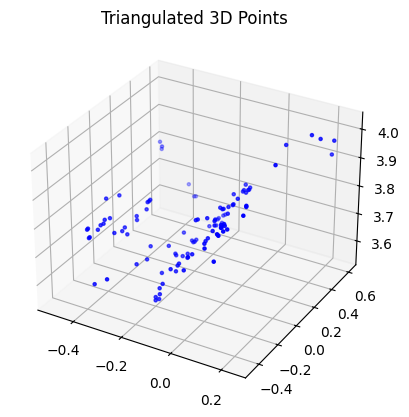

[output not shown]

```python
##################################################
# Part 4 - 5: Triangluation and Data Visualization
# 1) visualize_3d_points(X_3D)
#    - 3D scatter plot of Nx3 points
# 2) reprojection_error(P, X_3D, pts2d)
#    - Mean 2D error for Nx3 points vs Nx2 correspondences
##################################################

def visualize_3d_points(X_3D):
    """
    Displays a 3D scatter of the Nx3 points in X_3D.
    Usage:
        visualize_3d_points(X_3D)
    """
    fig = plt.figure()
    ax = fig.add_subplot(111, projection='3d')
    ax.scatter(X_3D[:, 0], X_3D[:, 1], X_3D[:, 2], s=5, c='blue')
    ax.set_title("Triangulated 3D Points")
    plt.show()

def reprojection_error(P, X_3D, pts2d):
    """
    Computes mean reprojection error for Nx3 3D points.
    Each 3D point is projected into image coords,
    then compared with the Nx2 input pts2d.

    Args:
        P:     3x4 camera matrix
        X_3D:  Nx3 array of 3D points
        pts2d: Nx2 array of 2D points
    Returns:
        error: scalar float (mean Euclidean distance)
    """
    # Convert 3D -> homogeneous
    X_hom = np.hstack([X_3D, np.ones((X_3D.shape[0], 1))])
    proj = (P @ X_hom.T).T   # Nx3
    proj_2d = proj[:, :2] / proj[:, 2:3]

    # Mean Euclidean error
    error = np.mean(np.linalg.norm(proj_2d - pts2d, axis=1))
    return error

##################################################
# Example usage (assuming X_3D was created):
# visualize_3d_points(X_3D)
# err1 = reprojection_error(P1, X_3D, pts1)
# err2 = reprojection_error(P2, X_3D, pts2)
# print("Cam1 reprojection error:", err1)
# print("Cam2 reprojection error:", err2)
##################################################
###########################################
# B31MV Assignment 3 – Part 4: Final Triangulation
#
# Steps:
#  1) Build the camera matrices P1, P2
#  2) Call triangulate_points(...) for all matched pts
#  3) (Optional) Visualize the 3D point cloud
###########################################

###########################################
# Final Triangulation
###########################################
def triangulate_points(P1, pts1, P2, pts2):
    """
    Reconstruct Nx2 correspondences into Nx3 3D points
    using the camera projection matrices P1 and P2.
    """
    N = pts1.shape[0]
    X_3D = np.zeros((N, 3))

    for i in range(N):
        x1, y1 = pts1[i]
        x2, y2 = pts2[i]

        # Build system A
        # A[i] = ...
        A = np.zeros((4,4))
        A[0] = y1 * P1[2] - P1[1]
        A[1] = x1 * P1[2] - P1[0]
        A[2] = y2 * P2[2] - P2[1]
        A[3] = x2 * P2[2] - P2[0]

        # Solve
        _, _, Vt = np.linalg.svd(A)
        X_hom = Vt[-1]
        X_hom /= X_hom[-1]  # from [X,Y,Z,W] to [X,Y,Z]
        X_3D[i] = X_hom[:3]

    return X_3D

###########################################
# (Optional) Quick 3D Visualization
###########################################
def visualize_3d_points(X_3D):
    """
    3D scatter plot for Nx3 points X_3D.
    """
    fig = plt.figure()
    ax = fig.add_subplot(111, projection='3d')
    ax.scatter(X_3D[:,0], X_3D[:,1], X_3D[:,2], s=5, c='blue')
    ax.set_title("Triangulated 3D Points")
    plt.show()

###########################################
# (Optional) Reprojection Error Calculation
# This function computes the reprojection error
# for a given camera matrix P and the corresponding 2D points pts2d.
###########################################
def reprojection_error(P, X_3D, pts2d):
    # Convert 3D -> homogeneous
    X_hom = np.hstack([X_3D, np.ones((len(X_3D),1))])
    proj = (P @ X_hom.T).T
    proj_2d = proj[:, :2] / proj[:, 2:3]
    err = np.mean(np.linalg.norm(proj_2d - pts2d, axis=1))
    return err

# Usage Example:
err1 = reprojection_error(P1, X_3D, pts1)
err2 = reprojection_error(P2, X_3D, pts2)
print("Reprojection Error - Cam1:", err1, "Cam2:", err2)


###########################################
# Example Usage (after Part 3):
###########################################
if __name__ == "__main__":
    # Suppose from Part 1 & 2 you have:
    # pts1, pts2, K1, K2, ...
    # F from eight-point
    # E = compute_essential_matrix(F, K1, K2)
    # (R_best, t_best) from choose_correct_RT(...)

    # 1) Build camera matrices
    # P1 = K1 [I|0]
    # P2 = K2 [R|t]
    # Then do final triangulation:
    # X_3D = triangulate_points(P1, pts1, P2, pts2)
    #
    # 2) Optionally visualize
    # visualize_3d_points(X_3D)
    #
    print("Part 4 code loaded. (Call triangulate_points + visualize_3d_points.)")

X_3D = triangulate_points(P1, pts1, P2, pts2)
visualize_3d_points(X_3D)  # if 'visualize_3d_points' doesn't have its own plt.show()
visualize_3d_points(X_3D)
plt.show()  # if 'visualize_3d_points' doesn't have its own plt.show()
```